# Linear Algebra

## Section 6 - Matrix operations - Addition, subtraction and multiplication

#### Scalar multiplication of matrices

- Exactly like with vectors
  - Simply multiply each element of the matrix by the scalar

#### Matrix additiona and subtraction

- Exactly like with vectors
  - Dimensions must be exactly the same
  - Add or subtract element-wise
  - If begin with a matrix and subtract the same matrix - end with a 0 matrix (special case)

#### Matrix multiplication

- Only two matrices can be multiplied together at once
  - The *inner dimensions* of the two matrices *must* be exactly the same
    - E.g. a 2x4 matrix could be multiplied by a 4x3 matrix, but not by a 3x4
    - The number of cols in matrix 1, must equal the number of rows in the second matrix
    - Multiply element-wise using the rows from the first matrix and the columns from the second
      - Then add the row/column products
    - The dimensions of the product will be the *outer dimensions* of the two products
    - Multiply first row of matrix A by first col of matrix B and add together
      - Then the first row of matrix A by second col of matrix B and sum
      - And repeat until reach last col
- **Vector multiplication**
  - Must be a row vector by a column vector, or column times row
  - 1xn times nx1 or nx1 times 1xn
  - Returns a scalar if 1xn times nx1
- Matrix multiplication is not commutative
  - **order matters!**
  - A * B != B * A

## Section 7 - Application - matrix operations, addition, subtraction, multiplication

1. Scalar multiplication of matrices

```r
A
```

```
     [,1] [,2]
[1,]   -1    2
[2,]    7    0
```

```r
2*A
```

```
     [,1] [,2]
[1,]   -2    4
[2,]   14    0
```

2. Matrix addition and subtraction
- Non-conformable arrays - dimensionality isn’t correct

```r
C <- matrix(c(-3, 0, 1, 7, 4, -6), nrow = 3, byrow = TRUE)
D <- matrix(c(-3, 0, 1, 7, 4, -6), nrow = 3, byrow = TRUE)

C - D
```

```
     [,1] [,2]
[1,]    0    0
[2,]    0    0
[3,]    0    0
```

3. Matrix multiplication
- Need to be careful with R commands
  - A * B -> doesn’t give the right answer
    - **Element-wise multiplication** - not true multiplication
  - A %*% B is what you want

```r
B %*% A
```

```
     [,1] [,2]
[1,]   -4   -6
[2,]   24   31
```

## Section 8 - LAB3 - Intro matrix operations addition subtraction and multiplication

```r
A <- matrix(1:12, nrow = 3, byrow = TRUE)
B <- matrix(1:8, nrow = 4, byrow = TRUE)
A
```

```
     [,1] [,2] [,3] [,4]
[1,]    1    2    3    4
[2,]    5    6    7    8
[3,]    9   10   11   12
```

```r
B
```

```
     [,1] [,2]
[1,]    1    2
[2,]    3    4
[3,]    5    6
[4,]    7    8
```

2. Explain why A and B cannot be added or subtracted. A and B cannot be added or subtracted because their dimensions are not the same
3. Create matrix C that can be added to A. Perform the addition.

```r
C <- matrix(13:24, nrow = 3, byrow = TRUE)
C
```

```
     [,1] [,2] [,3] [,4]
[1,]   13   14   15   16
[2,]   17   18   19   20
[3,]   21   22   23   24
```

```r
A + C
```

```
     [,1] [,2] [,3] [,4]
[1,]   14   16   18   20
[2,]   22   24   26   28
[3,]   30   32   34   36
```

4. Find AxB before multiplying in R, anticipate the dimensions of the product, and multiply by hand

```r
A %*% B
```

```
     [,1] [,2]
[1,]   50   60
[2,]  114  140
[3,]  178  220
```

## Section 8 - Matrix operations - matrix transposes and inverses

- **Transpose** - all of the elements switch positions
  - Switch row/col position between every element
  - If A is a 3X5 then A<sup>T</sup> is a 5x3 matrix
- **Inverse** of a matrix
  - The matrix *must* be square
  - Cannot have a row or column of all zeros
  - Another condition exists - but it is more technical. Won’t go into here, but quite rare
  - If all satisfied - matrix is *invertible*
- For 2x2 matrix A (matrix(c(a, b, c, d), nrows = 2, byrow = TRUE))
- All four elements are quotients
  - Denominator is the product of one diag minus product of other diag
  - Numerator
    - a and d have swapped places
    - b and c stay in the same place, but have been negated
  - As dimensionality increases - the process becomes more complex
- When a matrix is multiplied by its invese A*A<sup>-1</sup>
  - Returns an **identity matrix**
    - Any nxn matrix whose main diagonal is all 1s and has 0s everywhere else
    - Any matrix times its corresponding identity matrix will yield itself A*I = A (works like 1 in real number algebra)
    - Any matrix times its inverse yields the corresponding identity matrix A*A<sup>-1</sup> = I (analagous to any number times its reciprocal in real number algebra)

## Section 9 - Application - Matrix transposes and inverses

1. Matrix transpose
- The t function is handy, but needs a matrix type object passed to it
- It doesn’t work that well with a vector
- Always pass t() a matrix object

```r
v1.t <- t(v1)
v1.t
```

```
     [,1] [,2]
[1,]    5    6
```

2. Matrix inverse
- `A^-1` does not return the inverse - returns element wise reciprocation
- I.e. taking each element and dividing by 1
- If we want the inverse - `solve(A)`
- Don’t forget - only square matrices are invertible
- Matrix can not have a row or column of 0’s
  - Returns - the system is exactly singular
  - Means that the denominator is 0

```r
C <- matrix(c(1,2,0,0), nrow = 2)
C
```

```
     [,1] [,2]
[1,]    1    0
[2,]    2    0
```

```r
solve(C)
```

```
Error in solve.default(C) :
  Lapack routine dgesv: system is exactly singular: U[2,2] = 0
```

3. Identity matrix
- A matrix times its inverse gives the identity

```r
round(A %*% solve(A))
```

```
     [,1] [,2]
[1,]    1    0
[2,]    0    1
```

- Get the identity directly using `diag()`

```r
I3 <- diag(3)
I3
```

```
     [,1] [,2] [,3]
[1,]    1    0    0
[2,]    0    1    0
[3,]    0    0    1
```

```r
I7 <- diag(7)
I7
```

```
     [,1] [,2] [,3] [,4] [,5] [,6] [,7]
[1,]    1    0    0    0    0    0    0
[2,]    0    1    0    0    0    0    0
[3,]    0    0    1    0    0    0    0
[4,]    0    0    0    1    0    0    0
[5,]    0    0    0    0    1    0    0
[6,]    0    0    0    0    0    1    0
[7,]    0    0    0    0    0    0    1
```

- A matrix times the identity yields the matrix again

```r
A %*% I2
```

```
     [,1] [,2]
[1,]    1    2
[2,]    3    4
```

## Section 10 - Lab 4 - Intro Matrix Operations Transposes and Inverses

1. Define matrix A as a square matrix with entries of your choice.

```r
A <- matrix(1:9, nrow = 3, byrow = TRUE)
A
```

```
     [,1] [,2] [,3]
[1,]    1    2    3
[2,]    4    5    6
[3,]    7    8    9
```

2. Find the transpose of A - by hand and in R

```r
A.t <- t(A)
A.t
```

```
     [,1] [,2] [,3]
[1,]    1    4    7
[2,]    2    5    8
[3,]    3    6    9
```

3. Find the inverse of A, if it exists. If it does not exist, define a new matrix A that is invertible

```r
A4.inv = solve(A4)
A4.inv
```

```
          [,1]        [,2] [,3]
[1,]  1.066667  0.06666667 -0.8
[2,] -2.266667 -0.26666667  2.2
[3,]  0.200000  0.20000000 -0.4
```

4. Multiply A by its inverse. Before - what is the expected result?

```r
round(A4 %*% A4.inv)
```

```
     [,1] [,2] [,3]
[1,]    1    0    0
[2,]    0    1    0
[3,]    0    0    1
```

## Section 11 - What is linear regression

1. Definition and Generic Model Statement
- **Linear regression** - method of creating a *linear equation* to model the relationship between a dependent variable and one or more independent variable
2. Deterministic example
- Suppose you’re going to a baseball game.
  - Ticket cost = $20
  - Hot dogs $3
  - French fries $2
- Your total cost can be modelled as a linear function of the ticket price and the number of hot dogs and French fries you purchase
  - Total cost equals $20, plus $3 for every hot dog and $2 for every order of fries
  - Mathematically: c = 20 + 3h + 2f
  - h = no hot dogs, f = number of fries
  - Linear regression comes in when we only have the data and need to estimate the coefficients in the equation
3. Stochastic example

|  | mpg | cyl | disp | hp | drat | wt | qsec | vs | am | gear | carb |
| --- | --- | --- | --- | --- | --- | --- | --- | --- | --- | --- | --- |
| Mazda RX4 | 21.0 | 6 | 160.0 | 110 | 3.90 | 2.620 | 16.46 | 0 | 1 | 4 | 4 |
| Mazda RX4 Wag | 21.0 | 6 | 160.0 | 110 | 3.90 | 2.875 | 17.02 | 0 | 1 | 4 | 4 |
| Datsun 710 | 22.8 | 4 | 108.0 | 93 | 3.85 | 2.320 | 18.61 | 1 | 1 | 4 | 1 |
| Hornet 4 Drive | 21.4 | 6 | 258.0 | 110 | 3.08 | 3.215 | 19.44 | 1 | 0 | 3 | 1 |
| Hornet Sportabout | 18.7 | 8 | 360.0 | 175 | 3.15 | 3.440 | 17.02 | 0 | 0 | 3 | 2 |
| Valiant | 18.1 | 6 | 225.0 | 105 | 2.76 | 3.460 | 20.22 | 1 | 0 | 3 | 1 |
| Duster 360 | 14.3 | 8 | 360.0 | 245 | 3.21 | 3.570 | 15.84 | 0 | 0 | 3 | 4 |
| Merc 240D | 24.4 | 4 | 146.7 | 62 | 3.69 | 3.190 | 20.00 | 1 | 0 | 4 | 2 |
| Merc 230 | 22.8 | 4 | 140.8 | 95 | 3.92 | 3.150 | 22.90 | 1 | 0 | 4 | 2 |
| Merc 280 | 19.2 | 6 | 167.6 | 123 | 3.92 | 3.440 | 18.30 | 1 | 0 | 4 | 4 |

[output cut: 22 more lines]

- Suppose you wish to model *mpg* as a function of *wt* and *qsec*
  - The coefficients are unknown
  - Via linear regression the model is: mpg = 19.75 + (-5.05)*wt + 0.93* qsec + error
  - Coeffs - how much of a contribution to the independent variable do the dependent variables make

## Section 12 - Application - what is linear regression

1. Deterministic example
- Var1 -> hotdogs
- Var2 -> fries
- game-cost -> shows all different possible combinations of fries and hot.dogs

```r
hot.dog.model <- lm(Total.Cost ~ Hot.dogs + Fries, data=game.cost)
hot.dog.model
```

```
Call:
lm(formula = Total.Cost ~ Hot.dogs + Fries, data = game.cost)

Coefficients:
(Intercept)     Hot.dogs        Fries
         20            3            2
```

```r
summary(hot.dog.model)
```

```
essentially perfect fit: summary may be unreliable
```

```
Call:
lm(formula = Total.Cost ~ Hot.dogs + Fries, data = game.cost)

Residuals:
       Min         1Q     Median         3Q        Max
-6.965e-14 -1.799e-15 -5.900e-16  6.420e-16  2.230e-13

Coefficients:
             Estimate Std. Error   t value Pr(>|t|)
(Intercept) 2.000e+01  1.485e-15 1.347e+16   <2e-16 ***
Hot.dogs    3.000e+00  9.652e-17 3.108e+16   <2e-16 ***
Fries       2.000e+00  9.652e-17 2.072e+16   <2e-16 ***
---
Signif. codes:  0 ‘***’ 0.001 ‘**’ 0.01 ‘*’ 0.05 ‘.’ 0.1 ‘ ’ 1

Residual standard error: 1.227e-14 on 438 degrees of freedom
Multiple R-squared:      1, Adjusted R-squared:      1
F-statistic: 6.977e+32 on 2 and 438 DF,  p-value: < 2.2e-16
```

- Estimate column - shows the coefficients
2. Stochastic example

```r
mpg.model
```

```
Call:
lm(formula = mpg ~ wt + qsec, data = mtcars)

Coefficients:
(Intercept)           wt         qsec
    19.7462      -5.0480       0.9292
```

3. Model error

```r
mpg.model # Gives you the 'beta' vector
```

```
Call:
lm(formula = mpg ~ wt + qsec, data = mtcars)

Coefficients:
(Intercept)           wt         qsec
    19.7462      -5.0480       0.9292
```

```r
summary(mpg.model) # Gives you more detailed output
```

```
Call:
lm(formula = mpg ~ wt + qsec, data = mtcars)

Residuals:
    Min      1Q  Median      3Q     Max
-4.3962 -2.1431 -0.2129  1.4915  5.7486

Coefficients:
            Estimate Std. Error t value Pr(>|t|)
(Intercept)  19.7462     5.2521   3.760 0.000765 ***
wt           -5.0480     0.4840 -10.430 2.52e-11 ***
qsec          0.9292     0.2650   3.506 0.001500 **
---
Signif. codes:  0 ‘***’ 0.001 ‘**’ 0.01 ‘*’ 0.05 ‘.’ 0.1 ‘ ’ 1

Residual standard error: 2.596 on 29 degrees of freedom
Multiple R-squared:  0.8264,    Adjusted R-squared:  0.8144
F-statistic: 69.03 on 2 and 29 DF,  p-value: 9.395e-12
```

- Calculating error measures for the model

```r
root.mse <- sqrt(mean.squared.error)
root.mse
```

```
[1] 2.471485
```

# Section 13 - Lab 5 - Intro to What is Linear Regression

1. Download the ‘Baseball2018.csv’ dataset and load it into R using read.csv()
- No access to ‘Baseball2018.csv’

|  | mpg | cyl | disp | hp | drat | wt | qsec | vs | am | gear | carb |
| --- | --- | --- | --- | --- | --- | --- | --- | --- | --- | --- | --- |
| Mazda RX4 | 21.0 | 6 | 160.0 | 110 | 3.90 | 2.620 | 16.46 | 0 | 1 | 4 | 4 |
| Mazda RX4 Wag | 21.0 | 6 | 160.0 | 110 | 3.90 | 2.875 | 17.02 | 0 | 1 | 4 | 4 |
| Datsun 710 | 22.8 | 4 | 108.0 | 93 | 3.85 | 2.320 | 18.61 | 1 | 1 | 4 | 1 |
| Hornet 4 Drive | 21.4 | 6 | 258.0 | 110 | 3.08 | 3.215 | 19.44 | 1 | 0 | 3 | 1 |
| Hornet Sportabout | 18.7 | 8 | 360.0 | 175 | 3.15 | 3.440 | 17.02 | 0 | 0 | 3 | 2 |
| Valiant | 18.1 | 6 | 225.0 | 105 | 2.76 | 3.460 | 20.22 | 1 | 0 | 3 | 1 |
| Duster 360 | 14.3 | 8 | 360.0 | 245 | 3.21 | 3.570 | 15.84 | 0 | 0 | 3 | 4 |
| Merc 240D | 24.4 | 4 | 146.7 | 62 | 3.69 | 3.190 | 20.00 | 1 | 0 | 4 | 2 |
| Merc 230 | 22.8 | 4 | 140.8 | 95 | 3.92 | 3.150 | 22.90 | 1 | 0 | 4 | 2 |
| Merc 280 | 19.2 | 6 | 167.6 | 123 | 3.92 | 3.440 | 18.30 | 1 | 0 | 4 | 4 |

[output cut: 22 more lines]

2. Plot *Runs* vs. *HomeRun* and *Runs* vs. *H9*. Of *HomeRun* and *H9*, which appears to be more closely related to *Runs*? Plot *Runs* vs. *HomeRun* and *H9* in 3-space

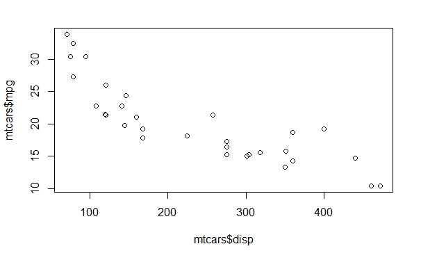